# Sorghastrum nutans, and the Comanche National Grassland

### Project description

In this project will assess habitat suitability for a particular grass species, over a geographical area. Based on the necessary growing conditions for the species selected, Raster data will be downloaded representing the ideal and tolerance ranges for variables such as soil pH and elevation. The raster data will then be used to determine which areas are suitable or not suitable for the grass species. The study areas selected were the Comanche National Grassland and Pawnee National Grassland, and the species is Sorghastrum nutans. The study will use data from the POLARIS (soil) and SRTM (elevation) databases, and a global climate model will be used from the MACA GCM compilation. These data sources will be used together to create a derived slope raster and habitat suitability rasters for Sorghastrum nutans.

### The Comanche National Grassland

The Comanche National Grassland in southeast Colorado consists of about 450,000 acres of land managed by the USDA Forest Service. It is split into two units. The Timpas region is further West, and possibly named after a Spanish word for a bar of iron, which is a reference to geological formations containing iron in that area. The name Carrizo refers to common reed grass, Phragmites australis. The Comanche National Grassland is named in honor of the Comanche tribe, which was centrally located here for 150 years, from approximately 1700-1850. The Comanche arrived in this area (indirectly) from Mexico, which is evident partly from words in their language such as "tecolotl", a word meaning "owl" which stems from the Aztec language Nahuatl. The Comanche competed over this area with the Ute and Apache tribes, which were eventually pushed out or migrated elsewhere. They eventually began to compete with Mexico as well, raiding Mexican settlements. These grasslands became the Comanche heartland, until they were asked to sign a treaty in 1853, and by 1880 they had ceased to have a presence there. (1)

### Species Descriptions

Sorghastrum nutans, colloquially known as indiangrass is a "tall, bunching sod-former, 3-8 ft. in height, with broad blue-green blades and a large, plume-like, soft, golden-brown seed head. This showy perennial’s fall color is deep orange to purple" (4). The optimal environmental conditions and tolerance ranges for Sorghastrum nutans are as follows:

(4, 5, 6)

### Changing climate, changing conditions

Plant species like Sorghastrum nutans and Phragmites australis rely on particular parameters for the suitability of their habitat, for example temperature, precipitation, and soil or ecosystem type. As the climate shifts, these parameters also shift, which changes the habitat characteristics and range of the species. In this study, I plan to use a climate model to project the distribution of these habitat parameters across the Comanche National Grassland for a future scenario.

### Methods:

The purpose of the project was to assess the suitabilty of habitat within the Comanche and Pawnee national grasslands for Sorghastrum nutans. To do this, several datasets were used. Soil pH was obtained from the POLARIS 30-m probabilistic maps. Elevation data was obtained from NASA via the Earthaccess python search tool, from the Shuttle Radar Topography Mission Global 1 arc second V003. Finally, a MACA (Multivariate Adaptive Constructed Analog) model was used to project precipitation values for the region into 2096 given an "extreme" rcp85 climate scenario. These datasets were harmonized to create a combined prediction of habitat viability for Sorghastrum nutans, given researched values for the plant's requirements for optimal growth and its survival tolerances.

Writing the code for this process proceeded in several steps. In notebook 1, National Grasslands boundaries vector data was downloaded. Two study areas were chosen from the National Grasslands: The Pawnee and Comanche National Grasslands. These were separated from the larger National Grasslands dataset and were plotted on top of ESRI imagery files. In notebook 2, code was written to access POLARIS soil pH rasters. First, a template URL was constructed that could be easily edited to code for different variables and study areas. A for loop was created to identify the bounds of the study areas, and compile a list of all rasters necessary within the bounds. In notebook 2a, the rasters within the list were then printed within a combined plot.

In notebook 3, code was written to login to earthaccess, from where the SRTMGL1 NASA Shuttle Radar Topography Mission Global 1 arc second V003 dataset was selected. This was then clipped to the Comanche and Pawnee bounds, and printed with the boundary overlaid on top. The SRTM for the Comanche grassland was then reprojected into UTM 13 N along with the grassland boundary, and rioxarray tools were used to derive a slope raster. The derived slope raster and Comanche grassland bounds were then plotted together. The same would have been done for the Pawnee grassland, however as this stage a bug was encountered which could not be fixed until much later. The Pawnee grassland raster could not be plotted, and only a blank plot with an axis in the middle would print. This was eventually fixed by editing the code used to select the soil data tiles, however due to time constraints, additional analysis of the Pawnee grassland was never completed.

In notebook 4, a code loop was written to access the MACA data. The code was written to be interoperable, and easily editable for testing additional variables or climate scenarios. For this model run, the variable selected was precipitation, the start year was 2096, the end year was 2099, and the climate scenario was rcp85, a 'more extreme' climate scenario. This selection was then clipped to the bounds of the Comanche National Grassland. Notebook 5 contains experimental starter code from my professor Lily Jones. It is intended to run a fuzzy logic model. Some parameters for the model were input, and some edits were made, however the model could not be made to run successfully.

Notebook 6 harmonizes the SRTM DEM with the MACA model. First, the precipitation values from the MACA model were plotted as a raster. These values were then assigned a suitability score of 0 (unsuitable) or 1 (suitable) based on the optimal rainfall and drought survival tolerances of Sorghastrum nutans. Similarly, a suitability raster was created from the DEM raster, giving a 1 or a 0 based on the elevation ranges at which nutans can grow. Finally, these rasters were multiplied to give a combined suitability raster for the 2096 rcp85 projected climate scenario. The resulting suitability raster showed that no location within the study bounds will be habitable for nutans in 2096, if the rcp85 climate scenario does indeed come to pass.

Given time for future study, there are a variety of ways in which this work could be expanded upon. First, it would be useful to complete the entire goal of the original study, which involved plotting suitability rasters for the Pawnee National Grassland and testing the model on at least one other variable. This would not be difficult, since the code to do this already exists: It would simply have to be edited to include the new study areas and variables, or copied into a new notebook from the original study. Second, the POLARIS soil pH rasters should be used to create suitability rasters. These could then be combined with the other variables or additonal scenarios to create composite suitability rasters. Third, if the fuzzy logic model could be completed, it would provide a more detailed and nuanced version of the suitability score. Instead of providing a binary raster with values of either suitable or unsuitable, the fuzzy logic model would create a decimal suitability score between one and zero. Finally, additional grass species, additional study areas, variables, and climate scenarios could all be tested and compared.

### Data Description

- Polaris: Polaris is a "probabilistic soil classification and property database over the contiguous United States at a 30-meter spatial resolution" (7). The database is an aggregation of several other sources of data including historical soil survey data and "readily available high-resolution environmental covariates". It uses modern high-speed computing to calculate soil rasters at 30 meter resolution, based on other available data. For a more detailed explanation of the probabilistic methods used to create these rasters, see "POLARIS Soiil Properties: 30-m Probabilistic Maps of Soil Properties over the Contiguous United States". (8), (Data Source: 9)
- SRTM: The Shuttle Radar Topography Mission (SRTM). The SRTM data was downloaded via Earthaccess, a Python API library that provides access to NASA's vast quantities of data (10). SRTM stands for Shuttle Radar Topography Mission, and it consisted of two radar antennas boosted to space via the space shuttle Endeavor. Together, the antennae managed to collect topographic data for 80% of the Earth's surface for the year 2000 (11). The dataset was 8.6 Terabytes, which was unprecedented at the time, and covered the areas between 60 degrees North and 56 degrees South at 30m resolution. To acquire the data, a technique called radio interferometry was used, which separated the two antennae by 60 meters and used the slight differences in their perspectives to calculate elevation. (12), (Data source: 13)
- MACA: MACA (Multivariate Adaptive Constructed Analog) datasets are based on GCM (Global Climate Model) data compiled within the CIMP5 framework. Global Climate Models are computational models that project future climate scenarios based on inputs such as ocean and atmospheric circulation, radiative heat transfer, and other factors. CIMP5 stands for the stands for phase 5 of the Climate Model Intercomparison Project. The CIMP5 project combined Global Climate Models from over 40 countries worldwide, and is currently the most extensive CIMP. However, due to the global nature of CIMP data, the resolution on these models is very low, often 100-300 km. MACA uses a statistical process to increase the resolution on these models, refining them to 4 or 6km resolution. (14), (Data source: 15), (16)
- RCP85 model: The RCP85 (Representative Concentration Pathways 8.5) represents a 'very high baseline emissions' climate scenario. The scenarios are based on radiative forcing, rather than on complex socioeconomic predictions. (model description: 17).
- USFS National Grasslands Boundaries: Boundaries for the Comanche and Pawnee National Grasslands were downloaded from the US Forest Service Enterprise Data Warehouse (EDW) (18)

Sources:

1. Donald L. Hazlett, Vascular Plant Species of the Comanche National Grassland in Southeatern Colorado, https://www.fs.usda.gov/rm/pubs/rmrs_gtr130.pdf
2. Colorado Encyclopedia, Pawnee National Grassland https://coloradoencyclopedia.org/article/pawnee-national-grassland#:~:text=History,sustained%20themselves%20by%20hunting%20bison.
3. US Forest Service, Pawnee National Grassland History https://www.fs.usda.gov/detail/arp/learning/history-culture/?cid=fsm91_058308
4. Plant Database, *Sorghastrum nutans*, https://www.wildflower.org/plants/result.php?id_plant=sonu2
5. Gemma Johnstone, 3/26/24, "How to Grow and Care for Wood Grass", https://www.thespruce.com/indian-grass-plant-profile-5069914
6. Natural Resources Conservation Service Plant Guide, Indiangrass, https://www.nrcs.usda.gov/plantmaterials/etpmcpg13196.pdf
7. Duke University, "Polaris - a probabilistic soil classification and property database over the contiguous United States at a 30-meter spatial resolution", https://otc.duke.edu/technologies/polaris-a-probabilistic-soil-classification-and-property-database-over-the-contiguous-united-states-at-a-30-meter-spatial-resolution/#:~:text=POLARIS%20%E2%80%93%20a%20probabilistic%20soil%20classification,meter%20spatial%20resolution%20%E2%80%94%20Duke%20OTC
8. Chaney et al., AGU Water Resources Research, "POLARIS Soil Properties: 30-m Probabilistic Maps of Soil Properties Over the Contiguous United States", https://agupubs.onlinelibrary.wiley.com/doi/full/10.1029/2018WR022797
9. Polaris data source, Duke University: http://hydrology.cee.duke.edu/POLARIS/PROPERTIES/v1.0/
10. Josh Blumenfeld, NASA EarthData, "Earthaccess: Earth Science Data Simplified" https://www.earthdata.nasa.gov/news/blog/earthaccess-earth-science-data-simplified
11. NASA EarthData, SRTM, https://www.earthdata.nasa.gov/data/instruments/srtm#:~:text=The%20Shuttle%20Radar%20Topography%20Mission,global%20dataset%20of%20land%20elevations.
12. NASA's Earth Observing System, Shuttle Radar Topography Mission (SRTM), https://eospso.nasa.gov/missions/shuttle-radar-topography-mission
13. SRTMGL1 NASA Shuttle Radar Topography Mission Global 1 arc second V003, Earthaccess, 12/15/2024
14. Climatology Lab, MACA, https://www.climatologylab.org/maca.html
15. Northwest Knowledge Network, http://thredds.northwestknowledge.net:8080/thredds/reacch_climate_CMIP5_macav2_catalog2.html
16. Earth Lab, 11/19/21, https://www.earthdatascience.org/courses/use-data-open-source-python/hierarchical-data-formats-hdf/intro-to-MACAv2-cmip5-data/
17. Carbon Brief, https://www.carbonbrief.org/explainer-the-high-emissions-rcp8-5-global-warming-scenario/
18. USFS National Grasslands boundaries, Enterprise Data Warehouse (EDW) 12/15/24, https://data.fs.usda.gov/geodata/edw/

```python
# Import tools
import os
import pathlib #finds the home folder
import pandas as pd
import geopandas as gpd
import matplotlib
import hvplot.pandas
import zipfile
import numpy
import xarray as xr
import rioxarray as rio
import cartopy as ccrs
import earthaccess
```

### Define a study area: Download the USFS National Grassland Units and select study sites. I selected Pawnee and Comanche National Grasslands.

##### Pseudocode outline:

- make the project directories
- conditional download grassland data only once
- use .plot to create maps of the grassland ecosystems

```python
# make the project directories

data_dir = os.path.join(
    pathlib.Path.home(),
    'earth-analytics',
    'data',
    'habitat_suitability'
)
os.makedirs(data_dir, exist_ok=True)
data_dir
```

```
'C:\\Users\\moenc\\earth-analytics\\data\\habitat_suitability'
```

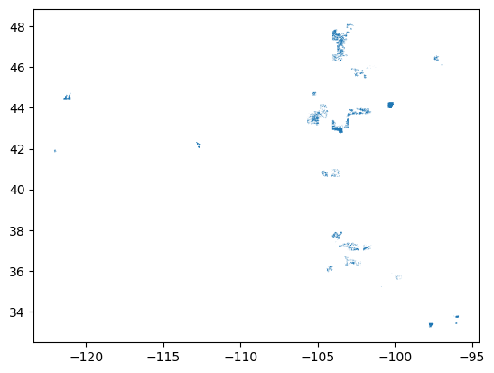

```python
# Define info for grasslands download
grasslands_url = (
    "https://data.fs.usda.gov/geodata/edw/edw_resources/"
    "shp/S_USA.NationalGrassland.zip"
)
grasslands_dir = os.path.join(data_dir, 'grasslands')
os.makedirs(grasslands_dir, exist_ok=True)
grasslands_path = os.path.join(grasslands_dir, 'grasslands.shp')

# Only download once
if not os.path.exists (grasslands_path):
    grasslands_gdf = gpd.read_file(grasslands_url)
    grasslands_gdf.to_file(grasslands_path)

# Load from file
grasslands_gdf = gpd.read_file(grasslands_path)

# Check the data
grasslands_gdf.plot()
```

Figure 1: above is a vector dataset containing all of the national grasslands. The Pawnee and Comanche national grasslands will need to be selected, and separated out from within this dataset.

```python
# Print the full grasslands_gdf. Note the NATIONALGR column.
grasslands_gdf
```

|  | NATIONALGR | GRASSLANDN | GIS_ACRES | SHAPE_AREA | SHAPE_LEN | geometry |
| --- | --- | --- | --- | --- | --- | --- |
| 0 | 281771010328 | Fort Pierre National Grassland | 209044.225 | 0.095149 | 1.455518 | POLYGON ((-100.08409 44.28162, -100.08409 44.2... |
| 1 | 295507010328 | Butte Valley National Grassland | 19489.170 | 0.008557 | 0.853736 | MULTIPOLYGON (((-121.996 41.84049, -121.996 41... |
| 2 | 295508010328 | Kiowa National Grassland | 144281.321 | 0.058543 | 9.858642 | MULTIPOLYGON (((-104.30414 36.08063, -104.3041... |
| 3 | 295509010328 | Sheyenne National Grassland | 70428.175 | 0.033356 | 4.097398 | MULTIPOLYGON (((-97.31081 46.51457, -97.30559 ... |
| 4 | 295510010328 | Cedar River National Grassland | 6717.517 | 0.003157 | 0.999947 | MULTIPOLYGON (((-101.82221 45.95896, -101.8170... |
| 5 | 295511010328 | Black Kettle National Grassland | 33103.349 | 0.013340 | 4.561060 | MULTIPOLYGON (((-99.91659 35.71892, -99.91661 ... |
| 6 | 295512010328 | Rita Blanca National Grassland | 94127.091 | 0.038271 | 6.652113 | MULTIPOLYGON (((-102.62993 36.44072, -102.6298... |
| 7 | 295513010328 | Thunder Basin National Grassland | 626249.208 | 0.282888 | 44.088050 | MULTIPOLYGON (((-105.46005 43.31908, -105.4601... |
| 8 | 295514010328 | McClellan Creek National Grassland | 1401.715 | 0.000562 | 0.115902 | POLYGON ((-100.86003 35.20951, -100.86008 35.2... |
| 9 | 295515010328 | Caddo National Grassland | 68479.549 | 0.026940 | 1.159342 | MULTIPOLYGON (((-95.85492 33.79814, -95.85494 ... |
| 10 | 295516010328 | Lyndon B. Johnson National Grassland | 115408.461 | 0.045238 | 1.177130 | POLYGON ((-97.67964 33.43396, -97.67951 33.433... |
| 11 | 295517010328 | Grand River National Grassland | 154665.301 | 0.072336 | 9.796405 | MULTIPOLYGON (((-102.08142 45.68619, -102.0814... |
| 12 | 295518010328 | Buffalo Gap National Grassland | 654877.177 | 0.295196 | 33.006274 | MULTIPOLYGON (((-102.33839 43.93678, -102.3383... |
| 13 | 295519010328 | Crooked River National Grassland | 173593.026 | 0.079499 | 2.815873 | POLYGON ((-120.98025 44.72935, -120.9803 44.72... |
| 14 | 295520010328 | Little Missouri National Grassland | 1025317.517 | 0.492748 | 60.421675 | MULTIPOLYGON (((-104.01688 47.51793, -104.0115... |
| 15 | 295521010328 | Oglala National Grassland | 215804.927 | 0.096279 | 1.970612 | POLYGON ((-103.72477 43.001, -103.72007 43.000... |
| 16 | 295522010328 | Comanche National Grassland | 444413.904 | 0.183064 | 26.658022 | MULTIPOLYGON (((-104.02263 37.69224, -104.0225... |
| 17 | 295523010328 | Pawnee National Grassland | 208424.885 | 0.089972 | 15.341594 | MULTIPOLYGON (((-104.58106 40.82664, -104.5810... |
| 18 | 295524010328 | Cimarron National Grassland | 109101.348 | 0.044765 | 5.539623 | MULTIPOLYGON (((-101.98977 37.11933, -101.9852... |
| 19 | 295525010328 | Curlew National Grassland | 74783.572 | 0.032983 | 1.771642 | MULTIPOLYGON (((-112.6995 42.2475, -112.6995 4... |

```python
# Define and print the boundary for the Pawnee National Grassland, with ESRI imagery as the background.
# For future runs of this code on different study areas, simply replace the "NATIONALGR" value
# on the first line below with the corresponding value for the new study area from the table above.

pawnee_gdf = grasslands_gdf[grasslands_gdf.NATIONALGR=='295523010328']
pawnee_gdf.dissolve().hvplot(
    geo=True, tiles='EsriImagery',
    title='Pawnee National Grassland',
    fill_color=None, line_color='black', line_width=1.5,
    frame_width=800
)
```

Figure 2: I successfully printed the boundary for the Pawnee National Grassland.

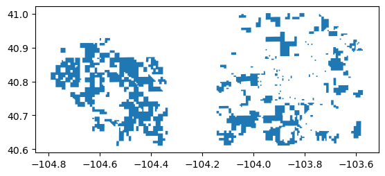

```python
pawnee_gdf.plot()
```

```python
# Define and print the Comanche National Grassland boundary, with ESRI imagery as the background.

comanche_gdf = grasslands_gdf[grasslands_gdf.NATIONALGR=='295522010328']
comanche_gdf.dissolve().hvplot(
    geo=True, tiles='EsriImagery',
    title='Comanche National Grassland',
    fill_color=None, line_color='black', line_width=1.5,
    frame_width=800
)
```

Figure 3: I successfuly printed out the boundary for the Comanche National Grassland.

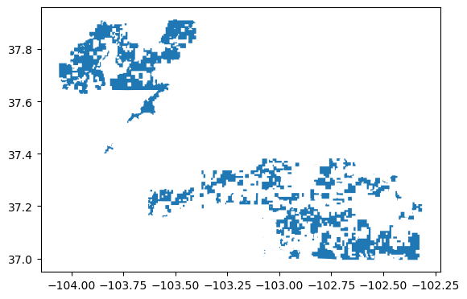

```python
comanche_gdf.plot()
```

```python
%store comanche_gdf pawnee_gdf
```

```
Stored 'comanche_gdf' (GeoDataFrame)
Stored 'pawnee_gdf' (GeoDataFrame)
```